# collatz_conjecture_R

```r
# load ggplot2 library for plotting
library(ggplot2, warn.conflicts = FALSE)
library(dplyr)
library(igraph)
```

## Visualizing the Collatz Sequence Formula

**Author:** Kyra Cho

The Collatz conjecture is a very well-known problem in mathematics.

The conjecture is innocently simple.

$$a_{n+1}=\begin{cases} 3a_n +1 \text{ if } a_n \text{ is odd}\\ \frac{a_n}{2} \text{ if } a_n \text{ is even.} \end{cases}$$

The Collatz conjecture posits that every sequence starting with any positive integer $a_n \in \mathbb{N}$ eventually reaches 1. The last time I checked the news, the conjecture has been verified for numbers up to $2.95 \times 10^{20}$, but still no proof exists. The problem is so well-known that some university courses are named after it. Paul Erdős once remarked that "math is not yet ripe enough for such problems." Mathematicians are often discouraged from spending time on this problem because it would probably consume all their efforts without yielding any results.

This exercise aims to visualize some patterns in the Collatz sequence using R and ggplot2, as a coding exercise.

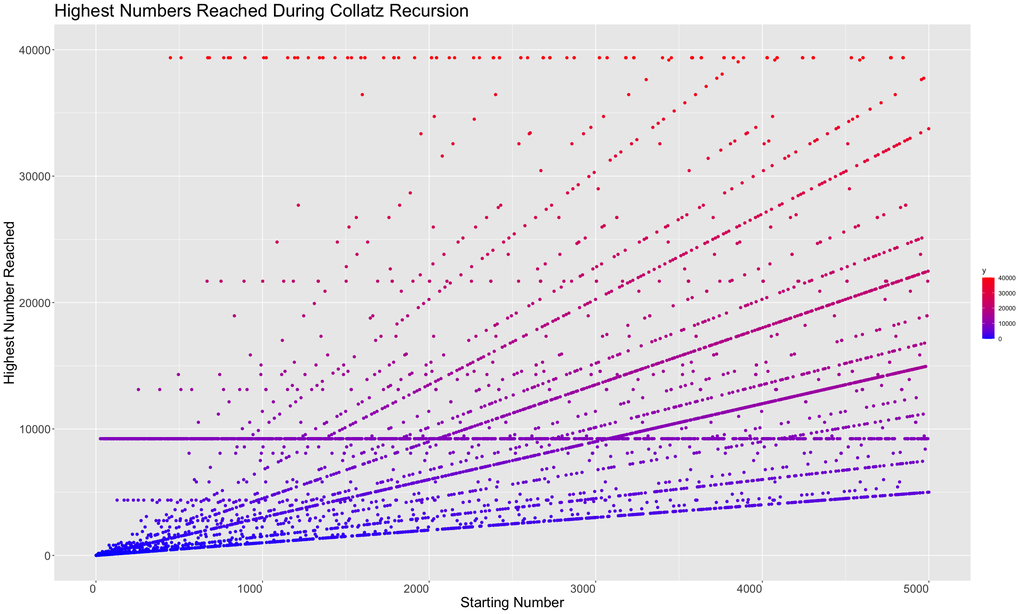

```r
# function to compute the Collatz recursion and record the highest number reached during the chain to 1
grapher <- function(n) {
  max_nums <- numeric(n)

  for (i in 1:n) {
    values <- numeric()
    a <- i

    for (j in 1:1000) {
      values <- c(values, a)
      if (a == 1) {
        break
      }
      if (a %% 2 == 1) {
        a <- 3 * a + 1
      } else {
        a <- a / 2
      }
    }

    max_nums[i] <- max(values)
  }

  return(max_nums)
}


# function to graph the highest numbers reached during the Collatz recursion
graph_max_nums <- function(n) {
    options(repr.plot.width = 20, repr.plot.height = 12)
    x <- 1:n
    y <- grapher(n)

    data <- data.frame(x = x, y = y)
    ggplot(data, aes(x = x, y = y, color = y)) +
        geom_point(na.rm=TRUE) +
        scale_color_gradient(low = "blue", high = "red", limits = c(0, 40000)) +
        theme(plot.title = element_text(size = 25)) +
        theme(axis.title = element_text(size = 20)) +
        theme(axis.text.x = element_text(size = 16, angle = 0, hjust = 1),
              axis.text.y = element_text(size = 16, angle = 0, hjust = 1)) +

        labs(title = "Highest Numbers Reached During Collatz Recursion",
            x = "Starting Number",
            y = "Highest Number Reached") +
        xlim(0, n) +  # Fixed x-axis limits
        ylim(0, 40000) # Fixed y-axis limits
}

# example usage: Plot the results for the first n numbers
graph_max_nums(5000)
```

This graph illustrates the peak values reached in the Collatz sequence for various starting numbers. Each point represents a starting integer and the maximum value encountered during its iteration through the Collatz conjecture steps. The plot shows diagonal rays emanating from the origin, as well as horizontal lines below 10000 and below 40000.

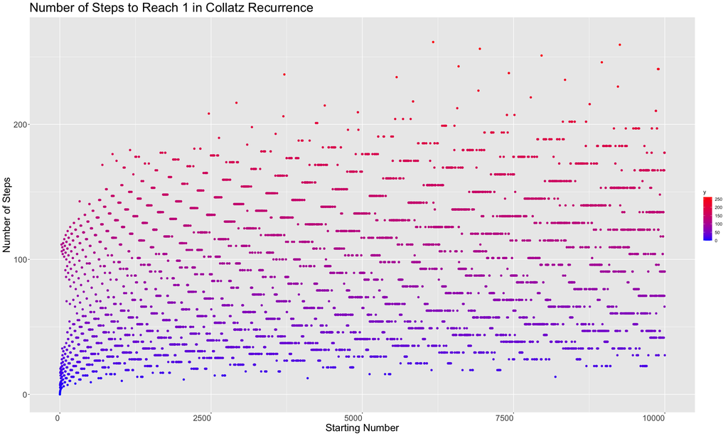

```r
# function to compute the number of steps for each number from 1 to n to reach 1 in the Collatz sequence
collatz_steps <- function(n) {
  steps <- numeric(n)

  for (i in 1:n) {
    count <- 0
    a <- i
    while (a != 1) {
      if (a %% 2 == 0) {
        a <- a / 2
      } else {
        a <- 3 * a + 1
      }
      count <- count + 1
    }
    steps[i] <- count
  }

  return(steps)
}

# function to graph the number of steps it takes to reach 1 in Collatz recurrence
graph_collatz_steps <- function(n) {
  # set the size of the plot
  options(repr.plot.width = 20, repr.plot.height = 12)

  x <- 1:n
  y <- collatz_steps(n)

  data <- data.frame(x = x, y = y)

  p <- ggplot(data, aes(x = x, y = y, color = y)) +
    geom_point() +
    scale_color_gradient(low = "blue", high = "red") +
    theme(plot.title = element_text(size = 25)) +
    theme(axis.title = element_text(size = 20)) +
    theme(axis.text.x = element_text(size = 16, angle = 0, hjust = 1),
          axis.text.y = element_text(size = 16, angle = 0, hjust = 1)) +
    labs(title = "Number of Steps to Reach 1 in Collatz Recurrence",
         x = "Starting Number",
         y = "Number of Steps") +
    xlim(0, n) +
    ylim(0, max(y) + 5) # adjust y-axis limit based on data

  print(p)
}

# plot the results for the first n numbers
graph_collatz_steps(10000)
```

This graph depicts the number of iterations needed for different starting numbers to reach 1 under the Collatz conjecture. Each point represents a starting integer and the total steps required to reduce it to 1 through the sequence.

[figure not shown]

```r
# Define the function to calculate total stopping time for the Collatz sequence
collatz_steps <- function(n) {
  steps <- 0
  while (n != 1) {
    if (n %% 2 == 0) {
      n <- n / 2
    } else {
      n <- 3 * n + 1
    }
    steps <- steps + 1
  }
  return(steps)
}

# Calculate the total stopping times for numbers 1 to 108
stopping_times <- sapply(1:10000, collatz_steps)

# Create a data frame from the stopping times
stopping_times_df <- data.frame(StoppingTime = stopping_times)

# Plot the histogram using ggplot2 with larger title and axes labels
ggplot(stopping_times_df, aes(x = StoppingTime)) +
  geom_histogram(binwidth = 1, fill = "skyblue", color = "black") +
  labs(title = "Histogram of Total Stopping Times for Numbers 1 to 10000",
       x = "Total Stopping Time",
       y = "Frequency") +
  theme_minimal() +
  theme(
    plot.title = element_text(size = 25),
    axis.title.x = element_text(size = 20),
    axis.title.y = element_text(size = 20),
    axis.text = element_text(size = 20)
  )
```

This histogram illustrates the distribution of total stopping times for the Collatz sequence starting with integers from 1 to 10000. The x-axis represents the total stopping time, while the y-axis indicates the frequency of each stopping time. The plot highlights the variability in the number of steps required for different starting numbers to reach 1.

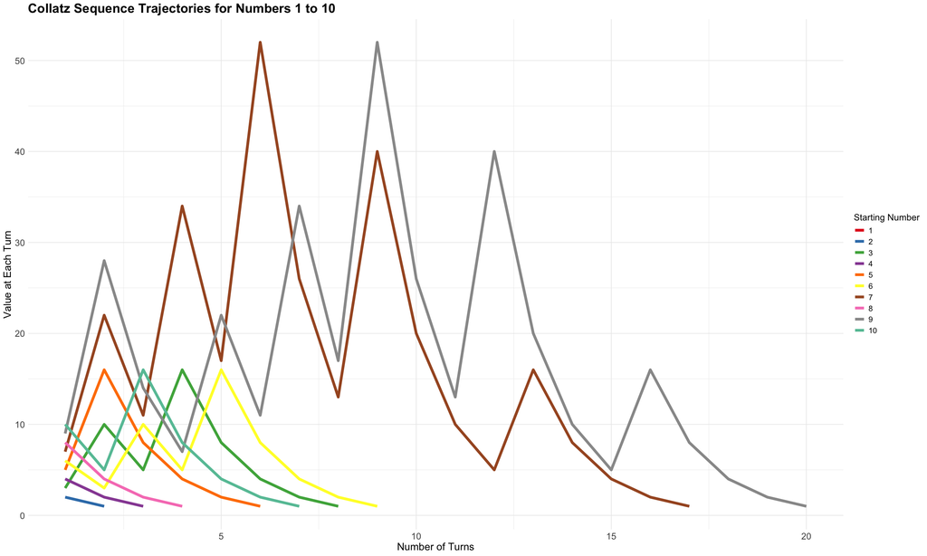

```r
# define the function to calculate the Collatz sequence for a given number
collatz_sequence <- function(n) {
  sequence <- c(n)
  while (n != 1) {
    if (n %% 2 == 0) {
      n <- n / 2
    } else {
      n <- 3 * n + 1
    }
    sequence <- c(sequence, n)
  }
  return(sequence)
}

# generate the sequences for numbers 1 to 10
sequences <- lapply(1:10, collatz_sequence)

# create a data frame from the sequences
df <- do.call(rbind, lapply(1:10, function(i) {
  data.frame(Number = i, Turn = seq_along(sequences[[i]]), Value = sequences[[i]])
}))

# define a color palette with 10 distinct colors
color_palette <- c(
  "#E41A1C", "#377EB8", "#4DAF4A", "#984EA3", "#FF7F00",
  "#FFFF33", "#A65628", "#F781BF", "#999999", "#66C2A5"
)

# plot the trajectories using ggplot2
ggplot(df, aes(x = Turn, y = Value, color = factor(Number))) +
  geom_line(linewidth = 2) +
  scale_color_manual(values = color_palette) +
  labs(title = "Collatz Sequence Trajectories for Numbers 1 to 10",
       x = "Number of Turns",
       y = "Value at Each Turn",
       color = "Starting Number") +
  theme_minimal() +
  theme(
    plot.title = element_text(size = 20, face = "bold"),
    axis.title.x = element_text(size = 16),
    axis.title.y = element_text(size = 16),
    axis.text = element_text(size = 14),
    legend.title = element_text(size = 14),
    legend.text = element_text(size = 12)
  )
```

This is a plot showing the trajectories of the Collatz sequence for numbers 1 to 10. Each line represents the sequence for a starting number, with the y-axis showing the value at each turn and the x-axis showing the number of turns. The colors differentiate the starting numbers.